# Final Project - Credit Card Fraud Detection

Ahsan Saeed, Chenyu Shen, Chi Zhang, Muhammad Waqas Aziz, Qian Li, Yawen Zheng

December 12, 2018

# Load libraries

```r
library(tidyverse)
library(tidymodels)
library(caret)
library(doParallel)
library(tidyverse)
library(pROC)
library(h2o)
library(DMwR)
library(e1071)
library(ROSE)
suppressMessages(library(reshape2))
suppressMessages(library(tidyverse))
suppressMessages(library(DataExplorer))
suppressMessages(library(ggplot2))
suppressMessages(library("gridExtra"))
library(grid)
library(ggplot2)
```

# 1. INTRODUCTION

Financial fraud is one of the biggest challenges that the financial companies across the globe face. According to report by Nilson Report, credit card frauds resulted in losses amounting to $21.84 billion during 2015. United States accounted for 38.7% of these frauds. (Source: Nilson Report, October 2016). Furthermore, on average, retailers incur $580.5 million in debit card fraud losses and spend $6.47 billion annually on credit and debit card fraud prevention annually (Source: Payments Journal, Feb. 2012).

Fraud can be defined as criminal deception with intent of acquiring financial gain. Over the last two decades, there has been an exponential increase in use of credit cards, particularly in online transactions. As a result the number of credit card frauds has also increased. Identifying fraudulent transactions among millions of transactions every day is extremely difficult. Data scientists around the globe are employing data mining techniques to predict fraudulent transactions. However, it is challenging due to two reasons. First, the profiles of fraudulent and normal behaviors change continuously and second, the fraud datasets are highly skewed (Source: Credit card fraud detection using machine learning techniques: A comparative analysis, John O. Awoyemi ; Adebayo O. Adetunmbi ; Samuel A. Oluwadare).

### DATA INTRODUCTION (SOURCE:KAGGLE)

The dataset contains transactions made by credit cards in September 2013 by European cardholders. This dataset presents transactions that occurred in two days, where we have 492 frauds out of 284,807 transactions. The dataset is highly unbalanced, the positive class (frauds) account for 0.172% of all transactions.

It contains only numerical input variables which are the result of a PCA transformation. Unfortunately, due to confidentiality issues, we cannot provide the original features and more background information about the data. Features V1, V2, … V28 are the principal components obtained with PCA, the only features which have not been transformed with PCA are ‘Time’ and ‘Amount’. Feature ‘Time’ contains the seconds elapsed between each transaction and the first transaction in the dataset. The feature ‘Amount’ is the transaction Amount, this feature can be used for example-dependant cost-senstive learning. Feature ‘Class’ is the response variable and it takes value 1 in case of fraud and 0 otherwise.

# 2. METHODS

## EXPLORATORY DATA ANALYSIS (EDA)

#### 1. Loading Data

```r
data = read_csv("creditcard.csv")
```

##### 1a. Checking for missing values

Lets see if the data has missing values

```r
introduce(data)
```

```
## # A tibble: 1 x 9
##     rows columns discrete_columns continuous_colu~ all_missing_col~
##    <int>   <int>            <int>            <int>            <int>
## 1 284807      31                0               31                0
## # ... with 4 more variables: total_missing_values <int>,
## #   complete_rows <int>, total_observations <int>, memory_usage <dbl>
```

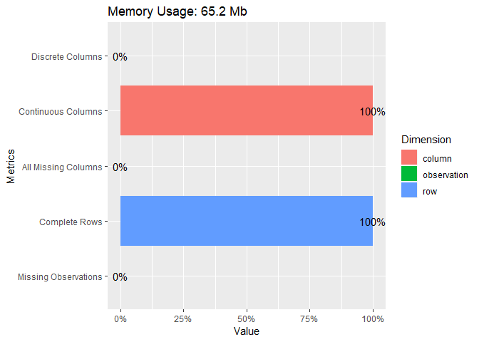

```r
plot_intro(data)
```

- There is only one missing value, lets see which variable has that missing value

##### Determining the missing value

```r
for (Var in names(data)) {
    missing <- sum(is.na(data[,Var]))
    if (missing > 0) {
        print(c(Var,missing))
    }
}
```

```
## [1] "Time" "1"
```

- So the Time variable has one missing value. Rest of the data is complete.

##### 1b. Checking for constant features

```r
flag <- FALSE

for (f in names(data)) {
  if (length(unique(data[[f]])) == 1) {
    cat(f, "\n")
     flag <- TRUE
  }
}

if (flag == FALSE){
     print ("no variable found to be constant")
}
```

```
## [1] "no variable found to be constant"
```

##### 1c. Checking for equal columns

```r
flag <- FALSE
features_pair <- combn(names(data), 2, simplify = F)
for(pair in features_pair) {
  f1 <- pair[1]
  f2 <- pair[2]

      if (all(data[[f1]] == data[[f2]])) {
      cat(f1, "and", f2, "are equals.\n")
           flag <- TRUE
    }
}

if (flag == FALSE){
     print ("No variables found as equal")
}
```

```
## [1] "No variables found as equal"
```

##### 1d. Data cleansing

```r
data=na.omit((data))
```

#### 2. Summary Statistics

First lets look at the summary statistics of all variable

```r
summary(data)
```

```
##       Time              V1                  V2
##  Min.   :     0   Min.   :-56.40751   Min.   :-72.71573
##  1st Qu.: 54201   1st Qu.: -0.92037   1st Qu.: -0.59854
##  Median : 84692   Median :  0.01811   Median :  0.06550
##  Mean   : 94814   Mean   :  0.00000   Mean   :  0.00001
##  3rd Qu.:139321   3rd Qu.:  1.31564   3rd Qu.:  0.80373
##  Max.   :172792   Max.   :  2.45493   Max.   : 22.05773
##        V3                  V4                  V5
##  Min.   :-48.32559   Min.   :-5.683171   Min.   :-113.74331
##  1st Qu.: -0.89037   1st Qu.:-0.848642   1st Qu.:  -0.69160
##  Median :  0.17985   Median :-0.019848   Median :  -0.05434
##  Mean   : -0.00001   Mean   :-0.000001   Mean   :   0.00000
##  3rd Qu.:  1.02718   3rd Qu.: 0.743348   3rd Qu.:   0.61193
##  Max.   :  9.38256   Max.   :16.875344   Max.   :  34.80167
##        V6                 V7                  V8
##  Min.   :-26.1605   Min.   :-43.55724   Min.   :-73.21672
##  1st Qu.: -0.7683   1st Qu.: -0.55407   1st Qu.: -0.20863
##  Median : -0.2742   Median :  0.04010   Median :  0.02236
##  Mean   :  0.0000   Mean   :  0.00001   Mean   :  0.00000
##  3rd Qu.:  0.3986   3rd Qu.:  0.57044   3rd Qu.:  0.32735
##  Max.   : 73.3016   Max.   :120.58949   Max.   : 20.00721
##        V9                  V10                  V11
##  Min.   :-13.434066   Min.   :-24.588262   Min.   :-4.797473
##  1st Qu.: -0.643098   1st Qu.: -0.535422   1st Qu.:-0.762496
##  Median : -0.051429   Median : -0.092913   Median :-0.032757
##  Mean   : -0.000011   Mean   :  0.000004   Mean   :-0.000001
##  3rd Qu.:  0.597131   3rd Qu.:  0.453934   3rd Qu.: 0.739595
##  Max.   : 15.594995   Max.   : 23.745136   Max.   :12.018913
##       V12                  V13                 V14
##  Min.   :-18.683715   Min.   :-5.791881   Min.   :-19.214325
##  1st Qu.: -0.405566   1st Qu.:-0.648542   1st Qu.: -0.425581
##  Median :  0.140036   Median :-0.013573   Median :  0.050594
##  Mean   :  0.000007   Mean   :-0.000001   Mean   : -0.000002
##  3rd Qu.:  0.618239   3rd Qu.: 0.662506   3rd Qu.:  0.493142
##  Max.   :  7.848392   Max.   : 7.126883   Max.   : 10.526766
##       V15                 V16                 V17
##  Min.   :-4.498945   Min.   :-14.12985   Min.   :-25.162799
##  1st Qu.:-0.582875   1st Qu.: -0.46805   1st Qu.: -0.483750
##  Median : 0.048074   Median :  0.06642   Median : -0.065677
##  Mean   : 0.000011   Mean   :  0.00000   Mean   : -0.000002
```

[output cut: 22 more lines]

```
##  Max.   : 4.584549   Max.   :  7.519589   Max.   : 3.517346
##       V27                  V28                Amount
##  Min.   :-22.565679   Min.   :-15.43008   Min.   :    0.00
##  1st Qu.: -0.070840   1st Qu.: -0.05296   1st Qu.:    5.60
##  Median :  0.001342   Median :  0.01124   Median :   22.00
##  Mean   :  0.000000   Mean   :  0.00000   Mean   :   88.35
##  3rd Qu.:  0.091043   3rd Qu.:  0.07828   3rd Qu.:   77.17
##  Max.   : 31.612198   Max.   : 33.84781   Max.   :25691.16
##      Class
##  Min.   :0.000000
##  1st Qu.:0.000000
##  Median :0.000000
##  Mean   :0.001728
##  3rd Qu.:0.000000
##  Max.   :1.000000
```

##### Factoring the Class variable

```r
# Creating factor
data <- data %>%
     mutate(Class = as.factor(Class))
levels(data$Class) <- c('Normal', 'Fraud')

#ploting
table(data$Class)
```

```
##
## Normal  Fraud
## 284314    492
```

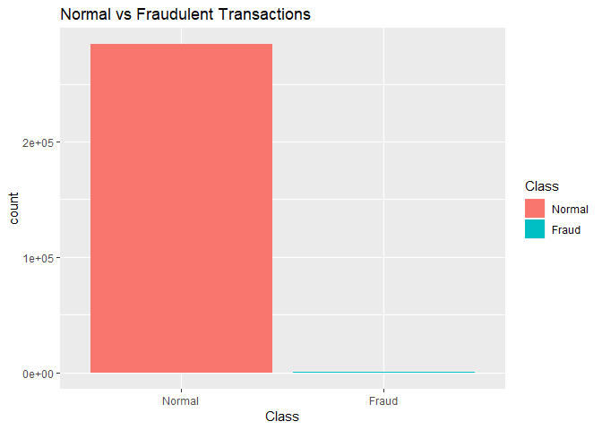

```r
ggplot(data)+
     geom_bar(aes(x = Class, fill = Class))+ggtitle("Normal vs Fraudulent Transactions")
```

##### Creating two separate data sets for Fraud and Clean transactions

```r
fraudData <- subset(data,Class=='Fraud')
notFraudData <- subset(data,Class=='Normal')
```

#### 3. Exploring if Fraud Transactions occur at specific time?

Time is defined as number of seconds elapsed between this transaction and the first transaction in the dataset

```r
# create new variable: night, based on Time variable
data_new<-na.omit(read_csv("creditcard.csv"))
data_new$Night <- as.factor((floor(data_new$Time/60/60)%%24 <= 9)*1)
```

#### Transactions divided per time of day

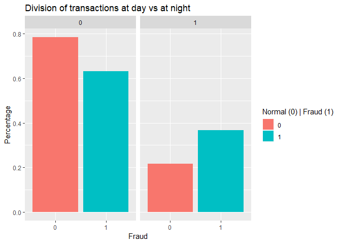

```r
toPlot <- data_new
toPlot$factClass <- as.factor(data_new$Class)
toPlot <- table(toPlot$Night, toPlot$factClass)
toPlot <- melt(toPlot)
toPlot$value[toPlot$Var2==0] = toPlot$value[toPlot$Var2==0]/sum(toPlot$value[toPlot$Var2==0])
toPlot$value[toPlot$Var2==1] = toPlot$value[toPlot$Var2==1]/sum(toPlot$value[toPlot$Var2==1])
names(toPlot) <- c("IsNight", "Fraud", "Percentage")
toPlot$Fraud <-as.factor(toPlot$Fraud)
ggplot(toPlot, aes(x=Fraud, y=Percentage, fill=Fraud))+geom_bar(stat="identity")+
  facet_grid(~IsNight)+
  ggtitle("Division of transactions at day vs at night")+
  scale_fill_discrete(name="Normal (0) | Fraud (1)")
```

- Fraud transactions are more likely to happen at night, comparing to normal transactions.
- Normal transactions are more likely to happen during the day than during the night
- Fraud transactions are more likely to happen during the day than during the night

#### Normal and Fraud transactions variation over time

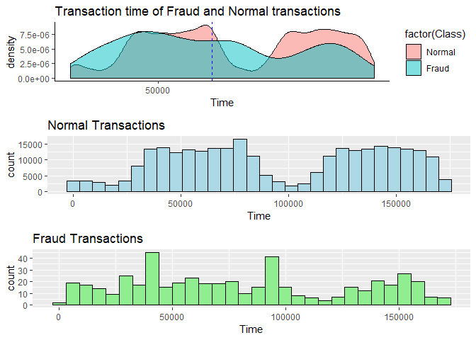

```r
p1 <- ggplot(notFraudData, aes(x = Time)) +
        geom_histogram(fill="light blue", colour = "black") + labs(title=expression("Normal Transactions"))

p2 <- ggplot(fraudData, aes(x = Time)) +
        geom_histogram(fill="light green", colour = "black") + labs(title=expression("Fraud Transactions"))

p3 <- ggplot(data = data,aes(x=Time,fill=factor(Class)))+geom_density(alpha=0.5)+
  geom_vline(aes(xintercept=mean(Time[Class=="Not Fraud"])),color="red",linetype="dashed",lwd=0.5)+
  geom_vline(aes(xintercept=mean(Time[Class=="Fraud"])),color="blue",linetype="dashed",lwd=0.5)+
       scale_x_continuous(breaks = seq(50000,100000,150000))+
  xlab(label = "Time") +
  ggtitle("Transaction time of Fraud and Normal transactions")+
  theme_classic()

grid.arrange(p3, p1, p2)
```

- We can clearly see that normal transactions follow a cyclical period. Therefore, if large number of transaction show up in low acitivity period it can raise an alarm

#### 4. Exploring if Fraud Transactions are related with amount of transaction?

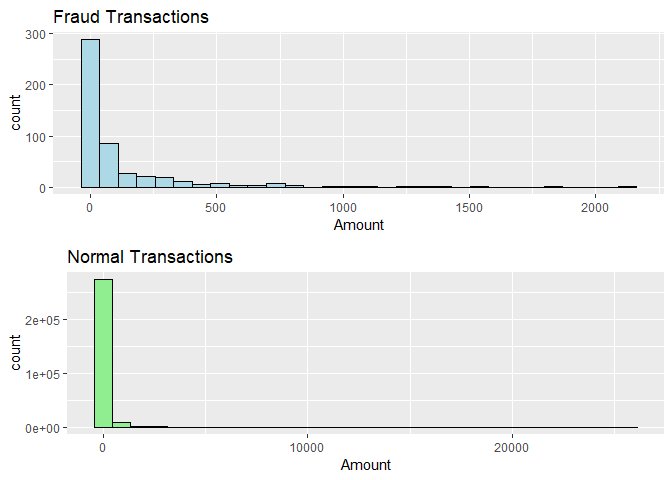

```r
p3 <- ggplot(fraudData, aes(x = Amount)) +
        geom_histogram(fill="light blue", colour = "black") + labs(title=expression("Fraud Transactions"))

p4 <- ggplot(notFraudData, aes(x = Amount)) +
        geom_histogram(fill="light green", colour = "black") + labs(title=expression("Normal Transactions"))

grid.arrange(p3, p4)
```

- No particular insights here, most of the transactions appear to be of small amount for both fraud and clean transactions. Lets further look into it by looking at its percentiles

#### Cumulative quintiles for Fraud and Normal transactions

```r
##Normal Transactions
quantile(notFraudData$Amount, seq(0, 1, by=.2))
```

```
##       0%      20%      40%      60%      80%     100%
##     0.00     3.58    13.03    37.00   100.00 25691.16
```

```r
##Fraud Transactions
quantile(fraudData$Amount, seq(0, 1, by=.2))
```

```
##       0%      20%      40%      60%      80%     100%
##    0.000    1.000    2.000   39.992  152.342 2125.870
```

- Clearly 60% of the transactions are of amount less than ~$40. Lets zoom into the transactions under $50 to see if there is an anomaly between fraud and clean transactions

#### Cumulative % graphs for Normal and Fraud transaction amounts

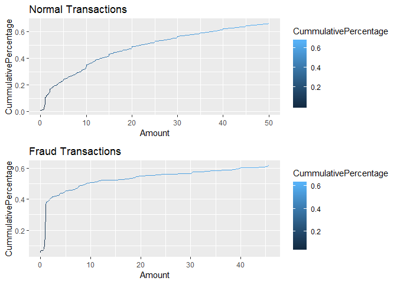

```r
tab <- melt(table(data$Amount[data$Class=='Normal']))
tab$CummulativePercentage <- cumsum(tab$value) / sum(tab$value) # cumulative Frequency
names(tab)[1] <- "Amount"
p5 <- ggplot(tab[tab$Amount<50,], aes(x=Amount, y=CummulativePercentage, color=CummulativePercentage))+
  geom_line()+ggtitle("Normal Transactions")

tab <- melt(table(data$Amount[data$Class=='Fraud']))
tab$CummulativePercentage <- cumsum(tab$value) / sum(tab$value)
names(tab)[1] <- "Amount"
p6 <- ggplot(tab[tab$Amount<50,], aes(x=Amount, y=CummulativePercentage, color=CummulativePercentage))+
  geom_line()+ggtitle("Fraud Transactions")

grid.arrange(p5, p6)
```

#### 5. Exploring if Fraud Transactions are related with amount and time of transaction?

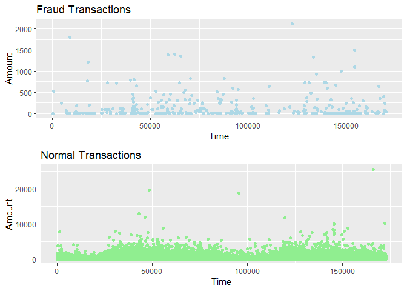

```r
p7<-ggplot(fraudData, aes(x=Time, y=Amount)) +
  geom_point(colour="light blue") + ggtitle("Fraud Transactions")

p8<-ggplot(notFraudData, aes(x=Time, y=Amount)) +
  geom_point(colour="light green")+ggtitle("Normal Transactions")

grid.arrange(p7, p8)
```

- Again, no particular anomaly here between fraud and normal transactions.

#### 6. Which variables explain the fraud transactions?

**We will use several methods to explore which variables can help in detecting the fraud transaction**

First,we need to look at the coorelation of all variablesto find a relation :

##### Correlation map

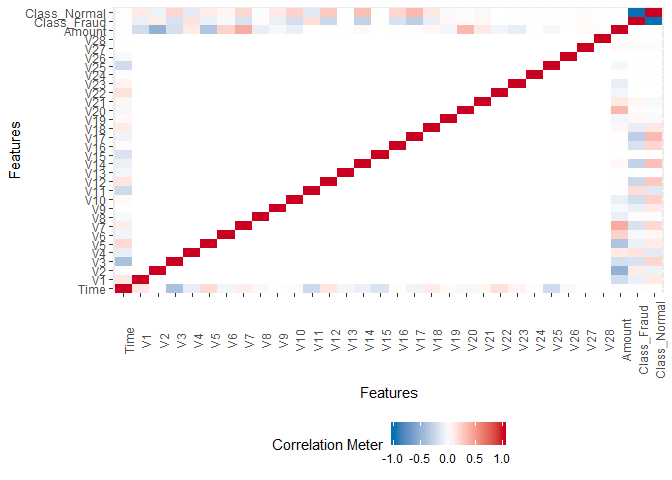

```r
plot_correlation(data, maxcat = 8L)
```

- None of the V1 to V28 PCA components have any correlation to each other.
- Little to no correlation between variables indicates that it is highly likely that ** data is pca transformed**
- Time has some correlations with V components but not with Amount.
- Amount also has some correlations with V components but not with Time.
- Class has some positive and negative correlations with the V components but has no significant correlation with Time and Amount.

##### Comparison of mean of variables by Fraud vs Normal transactions

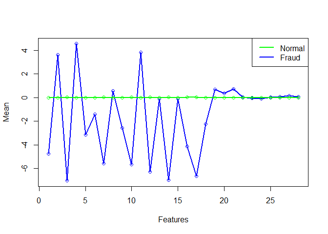

```r
skew <- sum(as.numeric(data$Class))/nrow(data)
mugood <- apply(notFraudData[sample(rownames(notFraudData), size = as.integer(skew *nrow(data)), replace = T), -c(1, 30, 31)], 2, mean)
muanom <- apply(fraudData[, -c(1, 30, 31)], 2, mean)
plot(muanom, col = "blue", xlab = "Features", ylab = "Mean")
lines(muanom, col = "blue", lwd = 2)
points(mugood, col = "green")
lines(mugood, col = "green", lwd = 2)
legend("topright", legend = c("Normal", "Fraud"), lty = c(1,1), col = c("green", "blue"), lwd = c(2,2))
```

- Mean values of variables for fraud transactions are different than for normal transactions for most of the variables.
- Mean values for the normal transacitons dont differ.
- Mean values for fraud transactions differ alot.

**Before we go into the detail of each variable, let’s look at the box plot for all the variables:**

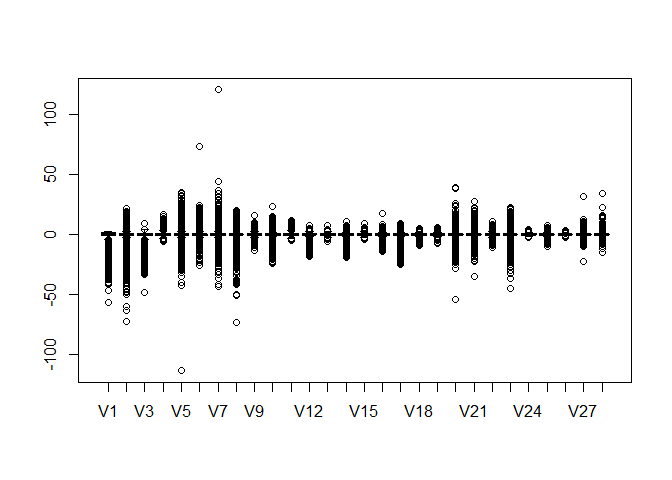

```r
boxplot(data[2:29])
```

- It is worth noticing that V13, V15, V19, and maybe V24 look very symmetrical. We will look at them in detail below
- Outliers appear to be a problem. However, outliers also help in detecting anomolies so we will not treat them. Lets look at the correlation map

##### Fraud vs Normal Transactions - deep diving into each variable

We will look into each variable to compare its distribution and variance using histogram and boxplots respectively and decide on if we should include the variable in the model

##### 1. V1

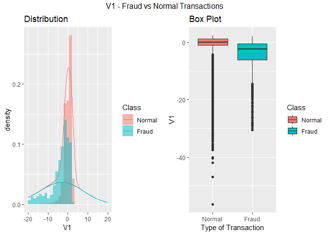

```r
p1 <- ggplot(data, aes(x = V1, fill = Class)) +
   geom_histogram(alpha = 0.5, aes(y = ..density..), position = 'identity') + stat_density(geom = "line", aes(colour = Class), adjust = 10) + xlim(-20,20 ) + labs(title=expression("Distribution"))

p2 <- ggplot(data, aes(y=V1, x=Class)) +  geom_boxplot(aes(fill = Class)) + labs(title=expression("Box Plot")) + xlab("Type of Transaction")

grid.arrange(p1, p2, top="V1 - Fraud vs Normal Transactions", ncol = 2)
```

- The distribution of v1 for fraud vs normal transaction have some overlap
- The box plot reflects that the variation is different for fraud vs normal transactions
- Therefore, this variable can be **useful** in predicting fraud

##### 2. V2

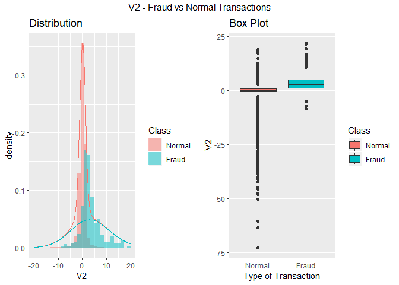

```r
p1 <- ggplot(data, aes(x = V2, fill = Class)) +
   geom_histogram(alpha = 0.5, aes(y = ..density..), position = 'identity') + stat_density(geom = "line", aes(colour = Class), adjust = 10) + xlim(-20,20 ) + labs(title=expression("Distribution"))

p2 <- ggplot(data, aes(y=V2, x=Class)) +  geom_boxplot(aes(fill = Class)) + labs(title=expression("Box Plot")) + xlab("Type of Transaction")

grid.arrange(p1, p2, top="V2 - Fraud vs Normal Transactions", ncol = 2)
```

##### 3. V3

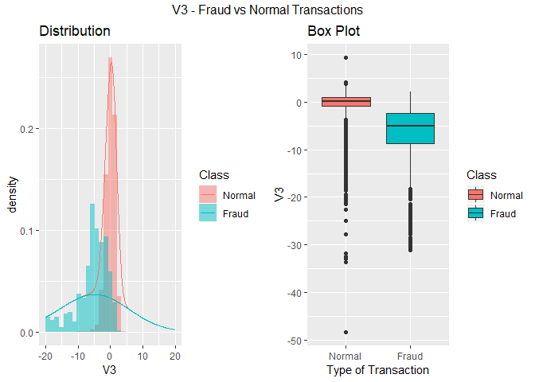

```r
p1 <- ggplot(data, aes(x = V3, fill = Class)) +
   geom_histogram(alpha = 0.5, aes(y = ..density..), position = 'identity') + stat_density(geom = "line", aes(colour = Class), adjust = 10) + xlim(-20,20 ) + labs(title=expression("Distribution"))

p2 <- ggplot(data, aes(y=V3, x=Class)) +  geom_boxplot(aes(fill = Class)) + labs(title=expression("Box Plot")) + xlab("Type of Transaction")

grid.arrange(p1, p2, top="V3 - Fraud vs Normal Transactions", ncol = 2)
```

- The distribution is partially similar
- The variability in data has some overlap but the mean is different
- Therefore, this variable is **useful** in predicting the fraud

##### 4. V4

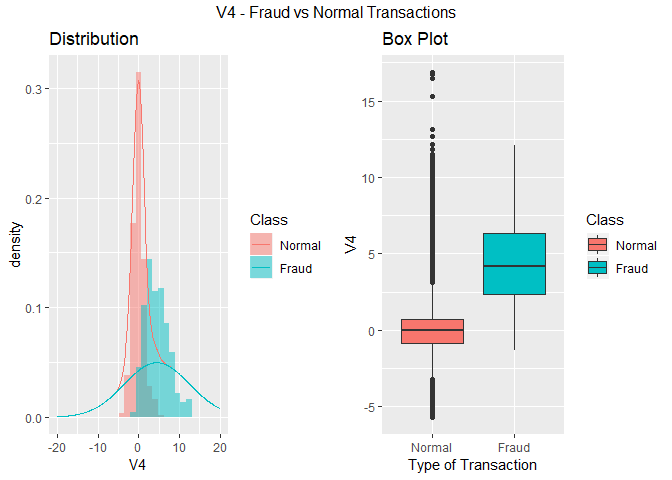

```r
p1 <- ggplot(data, aes(x = V4, fill = Class)) +
   geom_histogram(alpha = 0.5, aes(y = ..density..), position = 'identity') + stat_density(geom = "line", aes(colour = Class), adjust = 10) + xlim(-20,20 ) + labs(title=expression("Distribution"))

p2 <- ggplot(data, aes(y=V4, x=Class)) +  geom_boxplot(aes(fill = Class)) + labs(title=expression("Box Plot")) + xlab("Type of Transaction")

grid.arrange(p1, p2, top="V4 - Fraud vs Normal Transactions", ncol = 2)
```

##### 5. V5

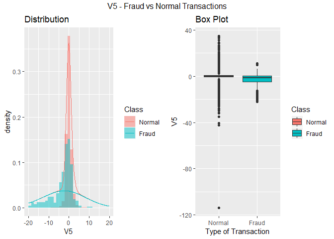

```r
p1 <- ggplot(data, aes(x = V5, fill = Class)) +
   geom_histogram(alpha = 0.5, aes(y = ..density..), position = 'identity') + stat_density(geom = "line", aes(colour = Class), adjust = 10) + xlim(-20,20 ) + labs(title=expression("Distribution"))

p2 <- ggplot(data, aes(y=V5, x=Class)) +  geom_boxplot(aes(fill = Class)) + labs(title=expression("Box Plot")) + xlab("Type of Transaction")

grid.arrange(p1, p2, top="V5 - Fraud vs Normal Transactions", ncol = 2)
```

- The distribution is very similar and there is a lot of overlap
- The variability in data has some overlap but very similar
- Therefore, this variable **may not be useful** in predicting the fraud

##### 6. V6

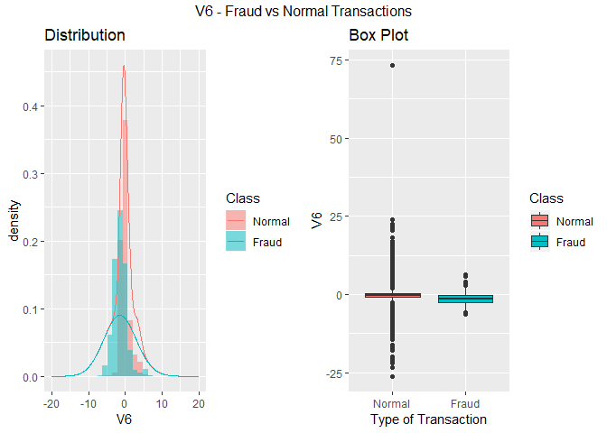

```r
p1 <- ggplot(data, aes(x = V6, fill = Class)) +
   geom_histogram(alpha = 0.5, aes(y = ..density..), position = 'identity') + stat_density(geom = "line", aes(colour = Class), adjust = 10) + xlim(-20,20 ) + labs(title=expression("Distribution"))

p2 <- ggplot(data, aes(y=V6, x=Class)) +  geom_boxplot(aes(fill = Class)) + labs(title=expression("Box Plot")) + xlab("Type of Transaction")

grid.arrange(p1, p2, top="V6 - Fraud vs Normal Transactions", ncol = 2)
```

- The distribution is very similar and it is largely overlapping, however there is some non-overlapping area as well
- The variability in data is similar
- it is on the boderline, so it could be **useful** lets keep this variable

##### 7. V7

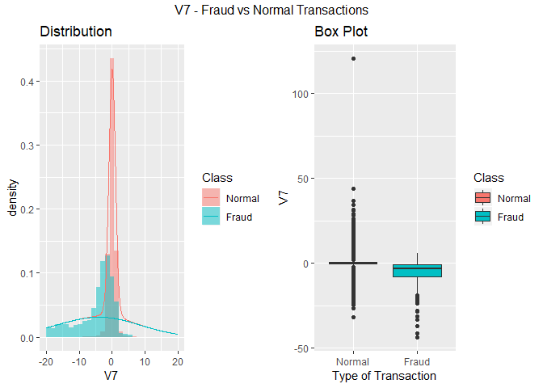

```r
p1 <- ggplot(data, aes(x = V7, fill = Class)) +
   geom_histogram(alpha = 0.5, aes(y = ..density..), position = 'identity') + stat_density(geom = "line", aes(colour = Class), adjust = 10) + xlim(-20,20 ) + labs(title=expression("Distribution"))

p2 <- ggplot(data, aes(y=V7, x=Class)) +  geom_boxplot(aes(fill = Class)) + labs(title=expression("Box Plot")) + xlab("Type of Transaction")

grid.arrange(p1, p2, top="V7 - Fraud vs Normal Transactions", ncol = 2)
```

##### 8. V8

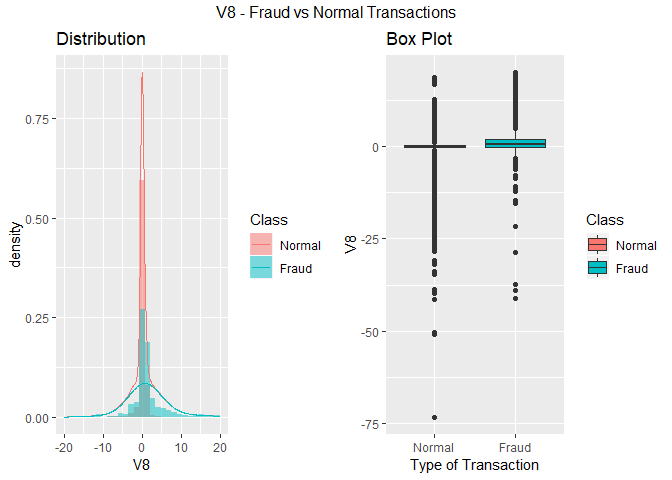

```r
p1 <- ggplot(data, aes(x = V8, fill = Class)) +
   geom_histogram(alpha = 0.5, aes(y = ..density..), position = 'identity') + stat_density(geom = "line", aes(colour = Class), adjust = 10) + xlim(-20,20 ) + labs(title=expression("Distribution"))

p2 <- ggplot(data, aes(y=V8, x=Class)) +  geom_boxplot(aes(fill = Class)) + labs(title=expression("Box Plot")) + xlab("Type of Transaction")

grid.arrange(p1, p2, top="V8 - Fraud vs Normal Transactions", ncol = 2)
```

- The distribution is very similar and there complete overlap
- The variability in data has some overlap but very similar
- Therefore, this variable **may not be useful** in predicting the fraud

##### 9. V9

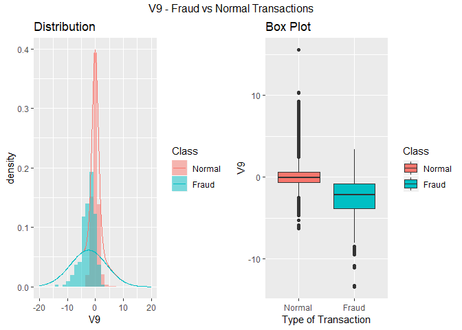

```r
p1 <- ggplot(data, aes(x = V9, fill = Class)) +
   geom_histogram(alpha = 0.5, aes(y = ..density..), position = 'identity') + stat_density(geom = "line", aes(colour = Class), adjust = 10) + xlim(-20,20 ) + labs(title=expression("Distribution"))

p2 <- ggplot(data, aes(y=V9, x=Class)) +  geom_boxplot(aes(fill = Class)) + labs(title=expression("Box Plot")) + xlab("Type of Transaction")

grid.arrange(p1, p2, top="V9 - Fraud vs Normal Transactions", ncol = 2)
```

- The distribution is very similar and there is a lot of overlap
- The variability in data has some overlap but very similar, thought they have somewhat different mean
- Therefore, this variable **may be useful** in predicting the fraud

##### 10. V10

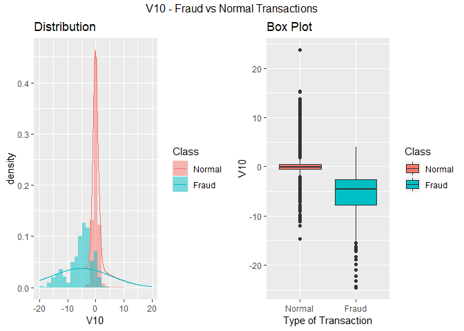

```r
p1 <- ggplot(data, aes(x = V10, fill = Class)) +
   geom_histogram(alpha = 0.5, aes(y = ..density..), position = 'identity') + stat_density(geom = "line", aes(colour = Class), adjust = 10) + xlim(-20,20 ) + labs(title=expression("Distribution"))

p2 <- ggplot(data, aes(y=V10, x=Class)) +  geom_boxplot(aes(fill = Class)) + labs(title=expression("Box Plot")) + xlab("Type of Transaction")

grid.arrange(p1, p2, top="V10 - Fraud vs Normal Transactions", ncol = 2)
```

- The distribution is very similar and there is a lot of overlap
- The variability in data has some overlap but most of them are different
- Therefore, this variable **may be useful** in predicting the fraud

##### 11. V11

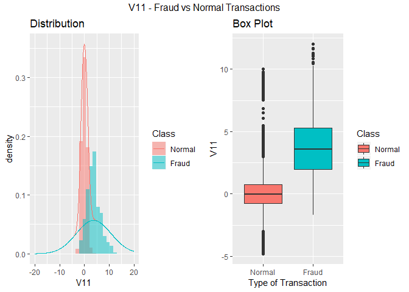

```r
p1 <- ggplot(data, aes(x = V11, fill = Class)) +
   geom_histogram(alpha = 0.5, aes(y = ..density..), position = 'identity') + stat_density(geom = "line", aes(colour = Class), adjust = 10) + xlim(-20,20 ) + labs(title=expression("Distribution"))

p2 <- ggplot(data, aes(y=V11, x=Class)) +  geom_boxplot(aes(fill = Class)) + labs(title=expression("Box Plot")) + xlab("Type of Transaction")

grid.arrange(p1, p2, top="V11 - Fraud vs Normal Transactions", ncol = 2)
```

- The distribution is partially different
- The variability in data has some overlap but mostly different
- Therefore, this variable is **useful** in predicting the fraud

##### 12. V12

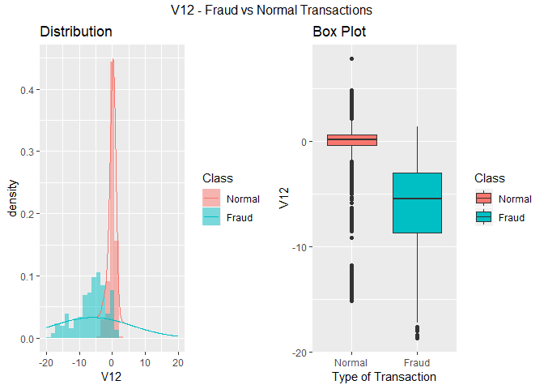

```r
p1 <- ggplot(data, aes(x = V12, fill = Class)) +
   geom_histogram(alpha = 0.5, aes(y = ..density..), position = 'identity') + stat_density(geom = "line", aes(colour = Class), adjust = 10) + xlim(-20,20 ) + labs(title=expression("Distribution"))

p2 <- ggplot(data, aes(y=V12, x=Class)) +  geom_boxplot(aes(fill = Class)) + labs(title=expression("Box Plot")) + xlab("Type of Transaction")

grid.arrange(p1, p2, top="V12 - Fraud vs Normal Transactions", ncol = 2)
```

- The distribution is very similar and there is a lot of overlap
- The variability in data has some overlap but mostly different
- Therefore, this variable may be **useful** in predicting the fraud

##### 13. V13

[figure not shown]

```r
p1 <- ggplot(data, aes(x = V13, fill = Class)) +
   geom_histogram(alpha = 0.5, aes(y = ..density..), position = 'identity') + stat_density(geom = "line", aes(colour = Class), adjust = 10) + xlim(-20,20 ) + labs(title=expression("Distribution"))

p2 <- ggplot(data, aes(y=V13, x=Class)) +  geom_boxplot(aes(fill = Class)) + labs(title=expression("Box Plot")) + xlab("Type of Transaction")

grid.arrange(p1, p2, top="V12 - Fraud vs Normal Transactions", ncol = 2)
```

**Fraud vs Normal comparison**

- The distribution is very similar and there is complete overlap
- The variability in data is also similar
- Therefore, this variable **may not be useful** in predicting the fraud

##### 14. V14

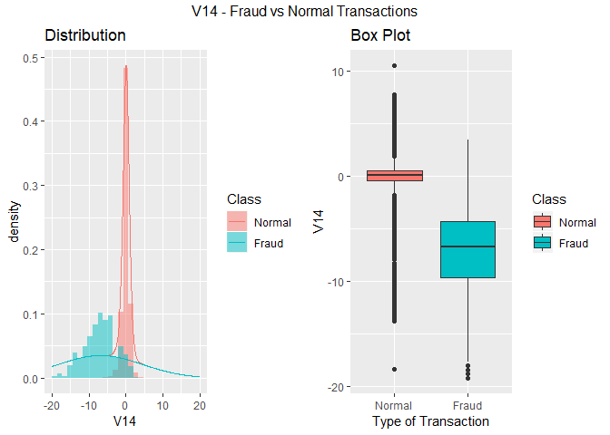

```r
p1 <- ggplot(data, aes(x = V14, fill = Class)) +
   geom_histogram(alpha = 0.5, aes(y = ..density..), position = 'identity') + stat_density(geom = "line", aes(colour = Class), adjust = 10) + xlim(-20,20 ) + labs(title=expression("Distribution"))

p2 <- ggplot(data, aes(y=V14, x=Class)) +  geom_boxplot(aes(fill = Class)) + labs(title=expression("Box Plot")) + xlab("Type of Transaction")

grid.arrange(p1, p2, top="V14 - Fraud vs Normal Transactions", ncol = 2)
```

**Fraud vs Normal comparison**

- The distribution is different for each class with one distribution skewed compared to the other
- There is significant variability between the Normal and Fraud transactions
- Therefore, this variable **may be useful** in predicting the fraud

##### 15. V15

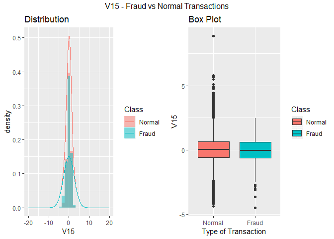

```r
p1 <- ggplot(data, aes(x = V15, fill = Class)) +
   geom_histogram(alpha = 0.5, aes(y = ..density..), position = 'identity') + stat_density(geom = "line", aes(colour = Class), adjust = 10) + xlim(-20,20 ) + labs(title=expression("Distribution"))

p2 <- ggplot(data, aes(y=V15, x=Class)) +  geom_boxplot(aes(fill = Class)) + labs(title=expression("Box Plot")) + xlab("Type of Transaction")

grid.arrange(p1, p2, top="V15 - Fraud vs Normal Transactions", ncol = 2)
```

**Fraud vs Normal comparison**

- The distribution is very similar and there is complete overlap
- The variability in data is also similar
- Therefore, this variable **may not be useful** in predicting the fraud

##### 16. V16

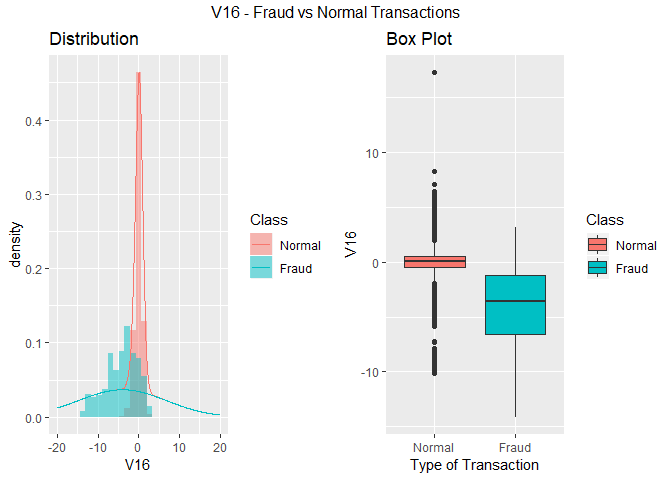

```r
p1 <- ggplot(data, aes(x = V16, fill = Class)) +
   geom_histogram(alpha = 0.5, aes(y = ..density..), position = 'identity') + stat_density(geom = "line", aes(colour = Class), adjust = 10) + xlim(-20,20 ) + labs(title=expression("Distribution"))

p2 <- ggplot(data, aes(y=V16, x=Class)) +  geom_boxplot(aes(fill = Class)) + labs(title=expression("Box Plot")) + xlab("Type of Transaction")

grid.arrange(p1, p2, top="V16 - Fraud vs Normal Transactions", ncol = 2)
```

**Fraud vs Normal comparison**

- The distribution is different for each class with one distribution skewed compared to the other
- There is significant variability between the Normal and Fraud transactions
- Therefore, this variable **may be useful** in predicting the fraud

##### 17. V17

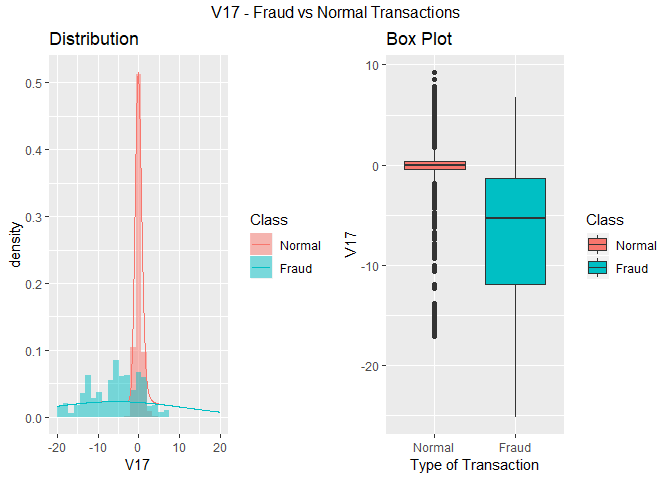

```r
p1 <- ggplot(data, aes(x = V17, fill = Class)) +
   geom_histogram(alpha = 0.5, aes(y = ..density..), position = 'identity') + stat_density(geom = "line", aes(colour = Class), adjust = 10) + xlim(-20,20 ) + labs(title=expression("Distribution"))

p2 <- ggplot(data, aes(y=V17, x=Class)) +  geom_boxplot(aes(fill = Class)) + labs(title=expression("Box Plot")) + xlab("Type of Transaction")

grid.arrange(p1, p2, top="V17 - Fraud vs Normal Transactions", ncol = 2)
```

**Fraud vs Normal comparison**

- The distribution is different for each class with one distribution skewed compared to the other
- There is significant variability between the Normal and Fraud transactions
- Therefore, this variable **may be useful** in predicting the fraud

##### 18. V18

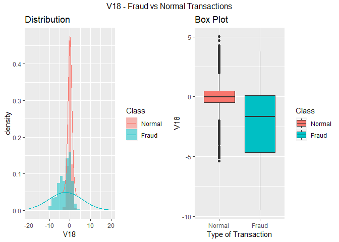

```r
p1 <- ggplot(data, aes(x = V18, fill = Class)) +
   geom_histogram(alpha = 0.5, aes(y = ..density..), position = 'identity') + stat_density(geom = "line", aes(colour = Class), adjust = 10) + xlim(-20,20 ) + labs(title=expression("Distribution"))

p2 <- ggplot(data, aes(y=V18, x=Class)) +  geom_boxplot(aes(fill = Class)) + labs(title=expression("Box Plot")) + xlab("Type of Transaction")

grid.arrange(p1, p2, top="V18 - Fraud vs Normal Transactions", ncol = 2)
```

**Fraud vs Normal comparison**

- The distribution is different for each class with one distribution skewed compared to the other
- There is significant variability between the Normal and Fraud transactions
- Therefore, this variable **may be useful** in predicting the fraud

##### 19. V19

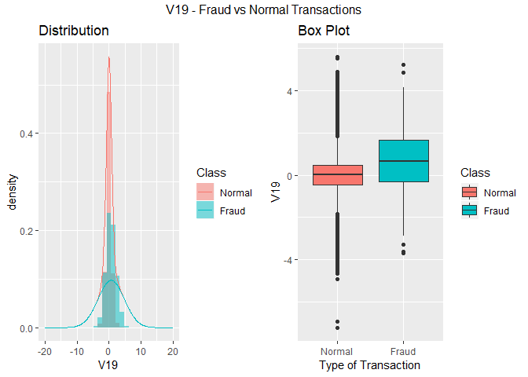

```r
p1 <- ggplot(data, aes(x = V19, fill = Class)) +
   geom_histogram(alpha = 0.5, aes(y = ..density..), position = 'identity') + stat_density(geom = "line", aes(colour = Class), adjust = 10) + xlim(-20,20 ) + labs(title=expression("Distribution"))

p2 <- ggplot(data, aes(y=V19, x=Class)) +  geom_boxplot(aes(fill = Class)) + labs(title=expression("Box Plot")) + xlab("Type of Transaction")

grid.arrange(p1, p2, top="V19 - Fraud vs Normal Transactions", ncol = 2)
```

**Fraud vs Normal comparison**

##### 20. V20

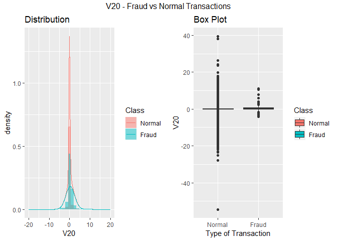

```r
p1 <- ggplot(data, aes(x = V20, fill = Class)) +
   geom_histogram(alpha = 0.5, aes(y = ..density..), position = 'identity') + stat_density(geom = "line", aes(colour = Class), adjust = 10) + xlim(-20,20 ) + labs(title=expression("Distribution"))

p2 <- ggplot(data, aes(y=V20, x=Class)) +  geom_boxplot(aes(fill = Class)) + labs(title=expression("Box Plot")) + xlab("Type of Transaction")

grid.arrange(p1, p2, top="V20 - Fraud vs Normal Transactions", ncol = 2)
```

**Fraud vs Normal comparison**

- The distribution is very similar and there is complete overlap
- The variability in data is also similar
- Therefore, this variable **may not be useful** in predicting the fraud

##### 21. V21

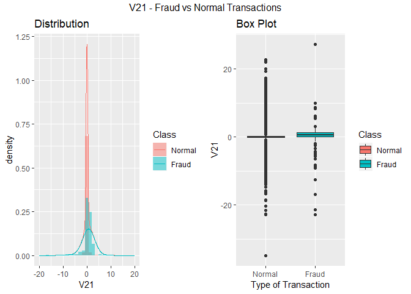

```r
p1 <- ggplot(data, aes(x = V21, fill = Class)) +
   geom_histogram(alpha = 0.5, aes(y = ..density..), position = 'identity') + stat_density(geom = "line", aes(colour = Class), adjust = 10) + xlim(-20,20 ) + labs(title=expression("Distribution"))

p2 <- ggplot(data, aes(y=V21, x=Class)) +  geom_boxplot(aes(fill = Class)) + labs(title=expression("Box Plot")) + xlab("Type of Transaction")

grid.arrange(p1, p2, top="V21 - Fraud vs Normal Transactions", ncol = 2)
```

**Fraud vs Normal comparison**

- The distribution is very similar and there is complete overlap
- The variability in data is also similar
- Therefore, this variable **may not be useful** in predicting the fraud

##### 22. V22

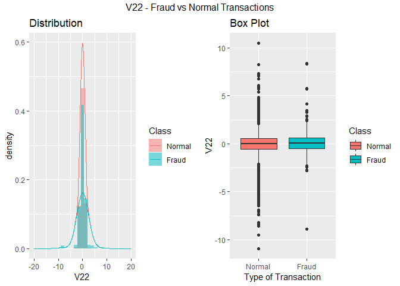

```r
p1 <- ggplot(data, aes(x = V22, fill = Class)) +
   geom_histogram(alpha = 0.5, aes(y = ..density..), position = 'identity') + stat_density(geom = "line", aes(colour = Class), adjust = 10) + xlim(-20,20 ) + labs(title=expression("Distribution"))

p2 <- ggplot(data, aes(y=V22, x=Class)) +  geom_boxplot(aes(fill = Class)) + labs(title=expression("Box Plot")) + xlab("Type of Transaction")

grid.arrange(p1, p2, top="V22 - Fraud vs Normal Transactions", ncol = 2)
```

**Fraud vs Normal comparison**

- The distribution is very similar and there is complete overlap
- The variability in data is also similar
- Therefore, this variable **may not be useful** in predicting the fraud